# STATS 500 HW1

Author

Minxuan Chen

Published

September 9, 2023

Github repo: https://github.com/PKUniiiiice/STATS_500

## Problem 1

The dataset `teengamb` concerns a study of teenage gambling in Britain.

**Glimpse**

```r
data(teengamb)
head(teengamb)
```

```
  sex status income verbal gamble
1   1     51   2.00      8    0.0
2   1     28   2.50      8    0.0
3   1     37   2.00      6    0.0
4   1     28   7.00      4    7.3
5   1     65   2.00      8   19.6
6   1     61   3.47      6    0.1
```

**Descriptive Statistics**

Note that `sex` is a categorical variable so here we only provide descriptions for the other variables.

```r
summary(teengamb[,2:5])
```

```
     status          income           verbal          gamble
 Min.   :18.00   Min.   : 0.600   Min.   : 1.00   Min.   :  0.0
 1st Qu.:28.00   1st Qu.: 2.000   1st Qu.: 6.00   1st Qu.:  1.1
 Median :43.00   Median : 3.250   Median : 7.00   Median :  6.0
 Mean   :45.23   Mean   : 4.642   Mean   : 6.66   Mean   : 19.3
 3rd Qu.:61.50   3rd Qu.: 6.210   3rd Qu.: 8.00   3rd Qu.: 19.4
 Max.   :75.00   Max.   :15.000   Max.   :10.00   Max.   :156.0
```

It seems that the variable `gamble` is heavily right-skewed.

**Distribution and Correlation**

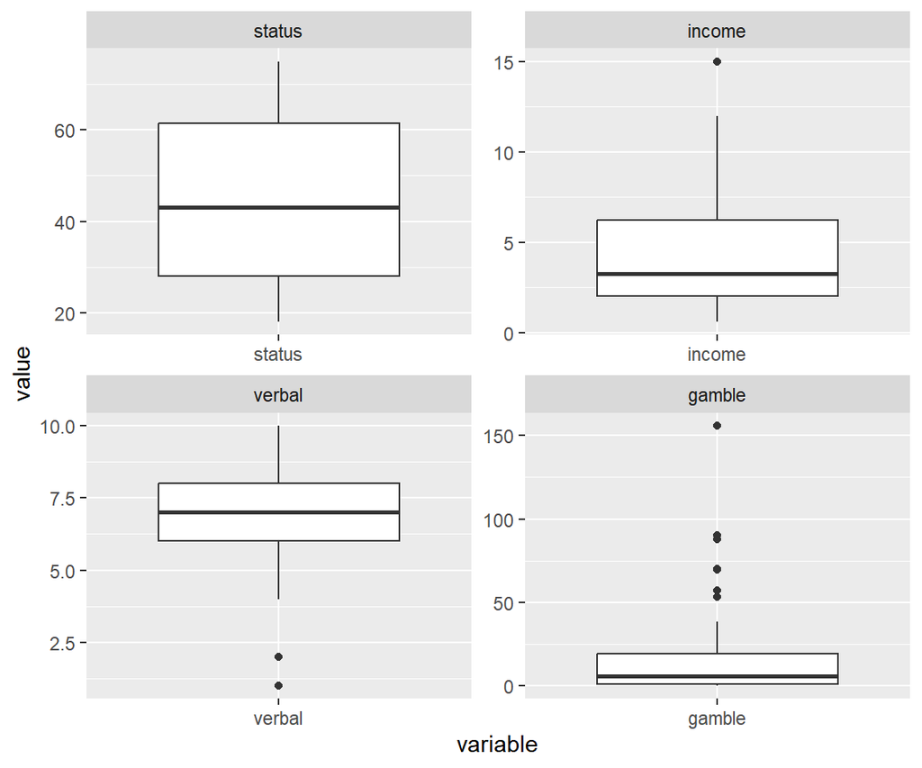

```r
md <- melt(teengamb[2:5], id.vars=NULL)
ggplot(md, aes(variable, value)) +
  geom_boxplot() +
  facet_wrap(~variable, scales="free")
```

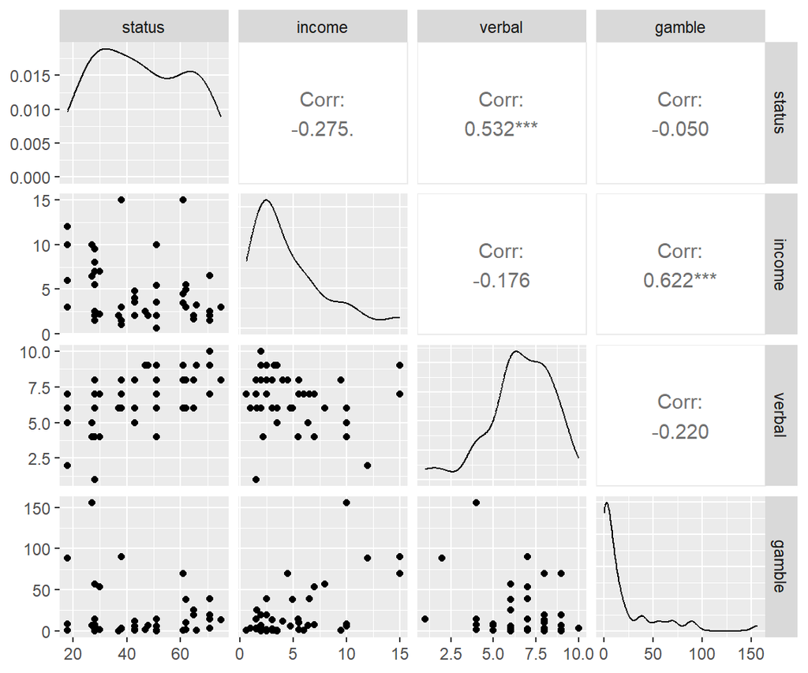

```r
ggpairs(teengamb[2:5])
```

In the boxplot, we can observe outliers in all variables except for `status`, with `gamble` having the highest number of outliers.

Regarding correlation, significant linear relationships are apparent between `status` and `verbal`, as well as between `income` and `gamble`. These relationships are consistent with the meanings of these variables.

**Gender Differences**

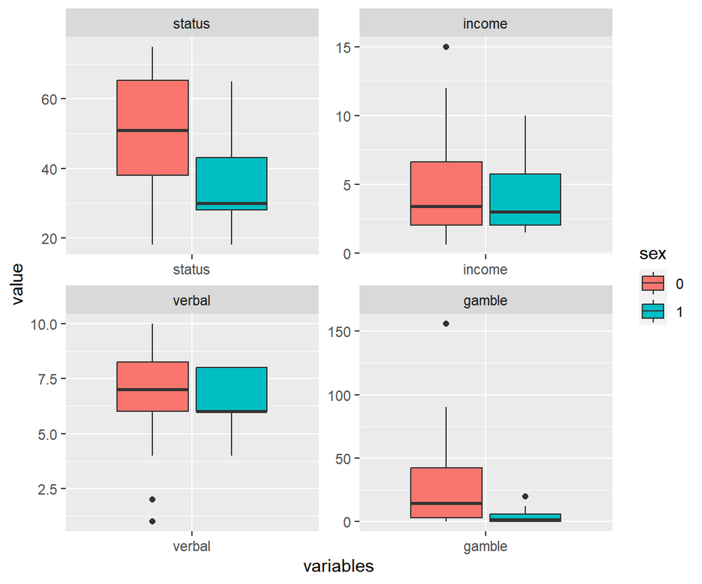

```r
teengamb$sex <- as.factor(teengamb$sex)
md <- melt(teengamb, id.var=c("sex"), var="variables")
p <- ggplot(data=md, aes(x=variables, y=value, fill=sex))+
     geom_boxplot()+
     facet_wrap(~variables, scale="free")
show(p)
```

In the variables `status` and `gamble`, there appears to be noticeable differences between males and females. Males tend to have higher socioeconomic status scores as well as higher expenditures on gambling.

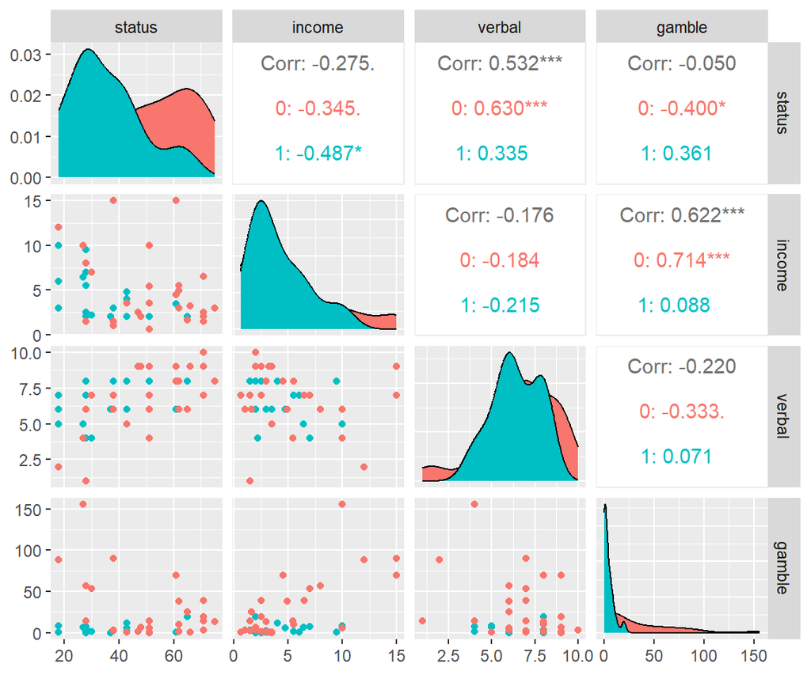

```r
ggpairs(teengamb, columns=2:5, ggplot2::aes(color=sex))
```

Note that in the relationships `status`-`verbal` and `income`-`gamble`, there are noticeable differences between males and females (i.e. different corr coef). For instance, in the case of `income`-`gamble`, in males, teenagers with higher income tend to have higher expenditures on gambling. However, in females, gambling expenditure remains low, regardless of their income level.

## Problem 2

### (a)

By definition, for $E(AZ)=AE(Z)$, we need to verify
$$[E(AZ)]_i = [AE(Z)]_i$$
Note that
$$\begin{aligned}[]
[E(AZ)]_i &= E([AZ]_i) \quad \text{(By def.)} \\
&=E\left(\sum_{j=1}^m A_{ij} Z_j \right) \\
&=\sum_{j=1}^m A_{ij} E(Z_j) \quad \text{(Linearity)} \\
&=\sum_{j=1}^m A_{ij} [E(Z)]_j \quad \text{(By def.)} \\
&=[AE(Z)]_i
\end{aligned}$$

Similarly, for $\operatorname{Cov}(AZ)=A\operatorname{Cov}(Z) A^\top$, we need to verify
$$\operatorname{Cov}(AZ)_{ij} = [A \operatorname{Cov}(Z) A^{\top}]_{ij}$$
Note that
$$\begin{aligned}
LHS &= \operatorname{Cov}([AZ]_i, [AZ]_j) \\
&=\operatorname{Cov}\left( \sum_{s=1}^m A_{is} Z_s , \sum_{t=1}^m A_{jt} Z_t \right)\\
&= \sum_{t=1}^m \sum_{s=1}^m A_{is} A_{jt} \operatorname{Cov}(Z_s,Z_t) \\
&= \sum_{t=1}^m \sum_{s=1}^m A_{is} A_{jt} \operatorname{Cov}(Z)_{st}
\end{aligned}$$
and
$$\begin{aligned}
RHS &= \left[A \operatorname{Cov} (Z) A^\top\right]_{ij} \\
&= \sum_{t=1}^m [A \operatorname{Cov} (Z)]_{it} \, [A^\top]_{tj} \\
&= \sum_{t=1}^m \left( \sum_{s=1}^m A_{is} \operatorname{Cov} (Z)_{st} \right) [A^\top]_{tj} \\
&= \sum_{t=1}^m \left( \sum_{s=1}^m A_{is} \operatorname{Cov} (Z)_{st} \right) A_{jt} \quad ( A_{jt} = [A^\top]_{tj}) \\
&= \sum_{t=1}^m \sum_{s=1}^m A_{is} A_{jt} \operatorname{Cov}(Z)_{st} \\
&=LHS
\end{aligned}$$

### (b)

```r
A <- matrix(c(1,1,-1,2,-2,2),ncol=2)
cov.z <- matrix(c(3,-1,-1,3),ncol=2)
cov.Y <- A%*%cov.z%*%t(A)
cov.Y
```

```
     [,1] [,2] [,3]
[1,]   11   -9    9
[2,]   -9   19  -19
[3,]    9  -19   19
```

and
$$\operatorname{Corr} (Y) = [\text{diag}( \operatorname{Cov} (Y))]^{-\frac{1}{2}} \operatorname{Cov} (Y) [\text{diag}( \operatorname{Cov} (Y))]^{-\frac{1}{2}}$$

```r
diag(diag(cov.Y)^(-1/2))%*%cov.Y%*%diag(diag(cov.Y)^(-1/2))
```

```
          [,1]      [,2]      [,3]
[1,]  1.000000 -0.622543  0.622543
[2,] -0.622543  1.000000 -1.000000
[3,]  0.622543 -1.000000  1.000000
```

## Problem 3

It’s known that
$$s_y = \sqrt{ \frac{1}{n} \sum_{i=1}^n\left(y_i-\bar{y}\right)^2}, s_x = \sqrt{ \frac{1}{n} \sum_{i=1}^n\left(x_i-\bar{x}\right)^2}$$
$$r = \frac{\frac{1}{n} \sum_{i=1}^n (x_i-\bar{x})(y_i-\bar{y}) }{s_x \cdot s_y}$$
We go from $y=\hat{\beta_0}+\hat{\beta_1}x$
$$\begin{aligned}
y &= \bar{y}-\hat{\beta_1} \bar{x} + \hat{\beta}_1x\\
&= \bar{y} + \hat{\beta}_1 (x-\bar{x}) \\
&= \bar{y} + \frac{\sum_{i=1}^n\left(x_i-\bar{x}\right)\left(y_i-\bar{y}\right)}{\sum_{i=1}^n\left(x_i-\bar{x}\right)^2} (x-\bar{x}) \\
&= \bar{y} + \frac{ n\cdot r \cdot s_x \cdot s_y } {\sum_{i=1}^n\left(x_i-\bar{x}\right)^2} (x-\bar{x}) \\
&= \bar{y} + \frac{ r \cdot s_x \cdot s_y } {\frac{1}{n}\sum_{i=1}^n\left(x_i-\bar{x}\right)^2} (x-\bar{x}) \\
&= \bar{y} + \frac{ r \cdot s_x \cdot s_y }{s_x^2}(x-\bar{x}) \\
\end{aligned}$$
Therefore, we have
$$\frac{y-\bar{y}}{s_y} = r\cdot \frac{x-\bar{x}}{s_x}$$